# Quality Control

```r
pacman::p_load(Seurat, tidyverse, qs2, scDblFinder, BiocParallel)
knitr::opts_knit$set(root.dir = "/home/han/Desktop/guoqiang/stroke_bm/stroke_bm_Rproj")
setwd("/home/han/Desktop/guoqiang/stroke_bm/stroke_bm_Rproj")
source("codes/functions.R")
```

### 1. Load Data

读入 11 例 10x 矩阵，写上分组、性别、年龄。

```r
all_data <- list()

all_data[["ctrl_1"]] <-
  Read10X(data.dir = "data/cr_output/220401M62/filtered_feature_bc_matrix") %>%
  CreateSeuratObject(project = "ctrl_1")
all_data[["ctrl_1"]]@meta.data <- all_data[["ctrl_1"]]@meta.data %>%
  mutate(sample = "CTRL-1", group = "CTRL", gender = "Male", age = 62)

all_data[["ctrl_2"]] <-
  Read10X(data.dir = "data/cr_output/CYM_SkullBM_240322/filtered_feature_bc_matrix") %>%
  CreateSeuratObject(project = "ctrl_2")
all_data[["ctrl_2"]]@meta.data <- all_data[["ctrl_2"]]@meta.data %>%
  mutate(sample = "CTRL-2", group = "CTRL", gender = "Female", age = 59)

all_data[["ctrl_3"]] <-
  Read10X(data.dir = "data/cr_output/LWN_SkullBM_240407/filtered_feature_bc_matrix") %>%
  CreateSeuratObject(project = "ctrl_3")
all_data[["ctrl_3"]]@meta.data <- all_data[["ctrl_3"]]@meta.data %>%
  mutate(sample = "CTRL-3", group = "CTRL", gender = "Male", age = 77)

all_data[["ctrl_4"]] <-
  Read10X(data.dir = "data/cr_output/LXY_SkullBM_240412/filtered_feature_bc_matrix") %>%
  CreateSeuratObject(project = "ctrl_4")
all_data[["ctrl_4"]]@meta.data <- all_data[["ctrl_4"]]@meta.data %>%
  mutate(sample = "CTRL-4", group = "CTRL", gender = "Female", age = 60)

all_data[["ctrl_5"]] <-
  Read10X(data.dir = "data/cr_output/STX_SkullBM_240229/filtered_feature_bc_matrix") %>%
  CreateSeuratObject(project = "ctrl_5")
all_data[["ctrl_5"]]@meta.data <- all_data[["ctrl_5"]]@meta.data %>%
  mutate(sample = "CTRL-5", group = "CTRL", gender = "Male", age = 30)

all_data[["ctrl_6"]] <-
  Read10X(data.dir = "data/cr_output/ZM_SkullBM_240620/filtered_feature_bc_matrix") %>%
  CreateSeuratObject(project = "ctrl_6")
all_data[["ctrl_6"]]@meta.data <- all_data[["ctrl_6"]]@meta.data %>%
  mutate(sample = "CTRL-6", group = "CTRL", gender = "Female", age = 30)

all_data[["aci_1"]] <-
  Read10X(data.dir = "data/cr_output/CBM_3/filtered_feature_bc_matrix") %>%
  CreateSeuratObject(project = "aci_1")
all_data[["aci_1"]]@meta.data <- all_data[["aci_1"]]@meta.data %>%
  mutate(sample = "ACI-1", group = "ACI", gender = "Male", age = 54)

all_data[["aci_2"]] <-
  Read10X(data.dir = "data/cr_output/CBM_4/filtered_feature_bc_matrix") %>%
  CreateSeuratObject(project = "aci_2")
all_data[["aci_2"]]@meta.data <- all_data[["aci_2"]]@meta.data %>%
  mutate(sample = "ACI-2", group = "ACI", gender = "Male", age = 75)

all_data[["aci_3"]] <-
  Read10X(data.dir = "data/cr_output/CBM_6/filtered_feature_bc_matrix") %>%
  CreateSeuratObject(project = "aci_3")
all_data[["aci_3"]]@meta.data <- all_data[["aci_3"]]@meta.data %>%
  mutate(sample = "ACI-3", group = "ACI", gender = "Male", age = 50)

all_data[["aci_4"]] <-
  Read10X(data.dir = "data/cr_output/CBM_5/filtered_feature_bc_matrix") %>%
  CreateSeuratObject(project = "aci_4")
all_data[["aci_4"]]@meta.data <- all_data[["aci_4"]]@meta.data %>%
  mutate(sample = "ACI-4", group = "ACI", gender = "Female", age = 65)

all_data[["aci_5"]] <-
  Read10X(data.dir = "data/cr_output/CBM_2/filtered_feature_bc_matrix") %>%
  CreateSeuratObject(project = "aci_5")
all_data[["aci_5"]]@meta.data <- all_data[["aci_5"]]@meta.data %>%
  mutate(sample = "ACI-5", group = "ACI", gender = "Male", age = 35)

qs_save(all_data, file = "data/rdata/preprocess/all_data.qs2", nthreads = 10)
```

### 2. Merge Layers

合成一个对象，方便后面统一质控。

```r
all_data <- qs_read("data/rdata/preprocess/all_data.qs2", nthreads = 10)
```

```r
all_data_qc <-
  merge(all_data[[1]], all_data[-1], add.cell.ids = names(all_data))
Layers(all_data_qc)
```

```
 [1] "counts.ctrl_1" "counts.ctrl_2" "counts.ctrl_3" "counts.ctrl_4"
 [5] "counts.ctrl_5" "counts.ctrl_6" "counts.aci_1"  "counts.aci_2"
 [9] "counts.aci_3"  "counts.aci_4"  "counts.aci_5"
```

```r
all_data_qc <- JoinLayers(all_data_qc)
rm(all_data)
Layers(all_data_qc)
```

```
[1] "counts"
```

```r
dim(all_data_qc)
```

```
[1] 38606 79488
```

```r
dim(all_data_qc@assays$RNA$counts)
```

```
[1] 38606 79488
```

```r
as.data.frame(all_data_qc@assays$RNA$counts[1:10, 1:2])
```

```
                ctrl_1_AAACCTGAGCCAGTAG-1 ctrl_1_AAACCTGAGTCCGGTC-1
DDX11L2                                 0                         0
MIR1302-2HG                             0                         0
FAM138A                                 0                         0
ENSG00000290826                         0                         0
OR4F5                                   0                         0
ENSG00000238009                         0                         0
ENSG00000239945                         0                         0
ENSG00000239906                         0                         0
ENSG00000241860                         0                         0
ENSG00000241599                         0                         0
```

```r
head(all_data_qc@meta.data, 10)
```

```
                          orig.ident nCount_RNA nFeature_RNA sample group
ctrl_1_AAACCTGAGCCAGTAG-1     ctrl_1      60591         7154 CTRL-1  CTRL
ctrl_1_AAACCTGAGTCCGGTC-1     ctrl_1        519          436 CTRL-1  CTRL
ctrl_1_AAACCTGCAAGCGCTC-1     ctrl_1      18100         4470 CTRL-1  CTRL
ctrl_1_AAACCTGCACACATGT-1     ctrl_1       2025         1244 CTRL-1  CTRL
ctrl_1_AAACCTGCAGACGCAA-1     ctrl_1       8300         3061 CTRL-1  CTRL
ctrl_1_AAACCTGCAGGTGCCT-1     ctrl_1        556          451 CTRL-1  CTRL
ctrl_1_AAACCTGTCAAGGTAA-1     ctrl_1        769          615 CTRL-1  CTRL
ctrl_1_AAACCTGTCACAATGC-1     ctrl_1        669          387 CTRL-1  CTRL
ctrl_1_AAACCTGTCGCGATCG-1     ctrl_1        580          308 CTRL-1  CTRL
ctrl_1_AAACCTGTCGGAGGTA-1     ctrl_1      31591         6887 CTRL-1  CTRL
                          gender age
ctrl_1_AAACCTGAGCCAGTAG-1   Male  62
ctrl_1_AAACCTGAGTCCGGTC-1   Male  62
ctrl_1_AAACCTGCAAGCGCTC-1   Male  62
ctrl_1_AAACCTGCACACATGT-1   Male  62
ctrl_1_AAACCTGCAGACGCAA-1   Male  62
ctrl_1_AAACCTGCAGGTGCCT-1   Male  62
ctrl_1_AAACCTGTCAAGGTAA-1   Male  62
ctrl_1_AAACCTGTCACAATGC-1   Male  62
ctrl_1_AAACCTGTCGCGATCG-1   Male  62
ctrl_1_AAACCTGTCGGAGGTA-1   Male  62
```

```r
all_data_qc@meta.data |>
  dplyr::select(orig.ident, sample) |>
  distinct()
```

```
                          orig.ident sample
ctrl_1_AAACCTGAGCCAGTAG-1     ctrl_1 CTRL-1
ctrl_2_AAACCTGAGGGAAACA-1     ctrl_2 CTRL-2
ctrl_3_AAACCTGAGAAACGAG-1     ctrl_3 CTRL-3
ctrl_4_AAACCTGAGACACTAA-1     ctrl_4 CTRL-4
ctrl_5_AAACCTGCATCGGACC-1     ctrl_5 CTRL-5
ctrl_6_AAACCTGAGAAACGAG-1     ctrl_6 CTRL-6
aci_1_AAACCAAAGCAATCTG-1       aci_1  ACI-1
aci_2_AAACCAAAGGTCATCA-1       aci_2  ACI-2
aci_3_AAACCAAAGCAAGGCA-1       aci_3  ACI-3
aci_4_AAACCAAAGATACTGT-1       aci_4  ACI-4
aci_5_AAACCAAAGCAATCGC-1       aci_5  ACI-5
```

### 3. Calcuate QC

算每个细胞的基因数、UMI、线粒体和核糖体比例。线粒体很高常见于濒死或破膜细胞。

```r
grep("^MT-", rownames(all_data_qc), value = TRUE)
```

```
 [1] "MT-ND1"  "MT-ND2"  "MT-CO1"  "MT-CO2"  "MT-ATP8" "MT-ATP6" "MT-CO3"
 [8] "MT-ND3"  "MT-ND4L" "MT-ND4"  "MT-ND5"  "MT-ND6"  "MT-CYB"
```

```r
grep("^RP[SL]", rownames(all_data_qc), value = TRUE)
```

```
  [1] "RPL22"       "RPL11"       "RPS6KA1"     "RPS8"        "RPL5"
  [6] "RPS27"       "RPS6KC1"     "RPS7"        "RPS27A"      "RPL31"
 [11] "RPL37A-DT"   "RPL37A"      "RPL32"       "RPL15"       "RPSA"
 [16] "RPL14"       "RPL29"       "RPL24"       "RPL22L1"     "RPL39L"
 [21] "RPL35A"      "RPL9"        "RPL34-DT"    "RPL34"       "RPS3A"
 [26] "RPL37"       "RPS23"       "RPS14"       "RPL26L1-AS1" "RPL26L1"
 [31] "RPS18"       "RPS10"       "RPL10A"      "RPL7L1"      "RPS12"
 [36] "RPS6KA2"     "RPS6KA2-IT1" "RPS6KA2-AS1" "RPS20"       "RPL7"
 [41] "RPL30"       "RPL30-AS1"   "RPL8"        "RPS6"        "RPL35"
 [46] "RPL12"       "RPL7A"       "RPS24"       "RPLP2"       "RPL27A"
 [51] "RPS13"       "RPS6KA4"     "RPS6KB2"     "RPS6KB2-AS1" "RPS3"
 [56] "RPS25"       "RPS26"       "RPL41"       "RPL6"        "RPLP0"
 [61] "RPL21"       "RPL10L"      "RPS29"       "RPL36AL"     "RPS6KL1"
 [66] "RPS6KA5"     "RPS27L"      "RPL4"        "RPLP1"       "RPS17"
 [71] "RPL3L"       "RPS2"        "RPS15A"      "RPL13"       "RPL26"
 [76] "RPL23A"      "RPL23"       "RPL19"       "RPL27"       "RPS6KB1"
 [81] "RPL38"       "RPL17"       "RPS15"       "RPL36"       "RPS28"
 [86] "RPL18A"      "RPSA2"       "RPS16"       "RPS19"       "RPL18"
 [91] "RPL13A"      "RPS11"       "RPS9"        "RPL28"       "RPS5"
 [96] "RPS21"       "RPL3"        "RPS19BP1"    "RPL23AP7"    "RPS6KA3"
[101] "RPS4X"       "RPS6KA6"     "RPL36A"      "RPL39"       "RPL10"
[106] "RPS4Y1"      "RPS4Y2"
```

```r
grep("^HB[ABDEGMQZ]\\d*$", rownames(all_data_qc), value = TRUE)
```

```
 [1] "HBB"  "HBD"  "HBG1" "HBG2" "HBE1" "HBZ"  "HBM"  "HBA2" "HBA1" "HBQ1"
```

```r
grep("PF4|PPBP", rownames(all_data_qc), value = TRUE)
```

```
 [1] "NBPF4"     "YIPF4"     "PRPF40A"   "PF4V1"     "PF4"       "PPBP"
 [7] "PPBPP2"    "PRPF4B"    "PRPF4"     "PRPF40B"   "APPBP2"    "APPBP2-DT"
```

```r
all_data_qc <- PercentageFeatureSet(
  all_data_qc,
  "^MT-",
  assay = "RNA",
  col.name = "percent_mt"
)
all_data_qc <- PercentageFeatureSet(
  all_data_qc,
  "^RP[SL]",
  assay = "RNA",
  col.name = "percent_rb"
)
all_data_qc <- PercentageFeatureSet(
  all_data_qc,
  "^HB[ABDEGMQZ]\\d*$",
  col.name = "percent_hb"
)
all_data_qc <- PercentageFeatureSet(
  all_data_qc,
  "PF4|PPBP",
  assay = "RNA",
  col.name = "percent_pt"
)
```

```r
head(all_data_qc[[]])
```

```
                          orig.ident nCount_RNA nFeature_RNA sample group
ctrl_1_AAACCTGAGCCAGTAG-1     ctrl_1      60591         7154 CTRL-1  CTRL
ctrl_1_AAACCTGAGTCCGGTC-1     ctrl_1        519          436 CTRL-1  CTRL
ctrl_1_AAACCTGCAAGCGCTC-1     ctrl_1      18100         4470 CTRL-1  CTRL
ctrl_1_AAACCTGCACACATGT-1     ctrl_1       2025         1244 CTRL-1  CTRL
ctrl_1_AAACCTGCAGACGCAA-1     ctrl_1       8300         3061 CTRL-1  CTRL
ctrl_1_AAACCTGCAGGTGCCT-1     ctrl_1        556          451 CTRL-1  CTRL
                          gender age percent_mt percent_rb percent_hb
ctrl_1_AAACCTGAGCCAGTAG-1   Male  62  2.3980459  27.223515 7.28821112
ctrl_1_AAACCTGAGTCCGGTC-1   Male  62  1.5414258  13.872832 0.19267823
ctrl_1_AAACCTGCAAGCGCTC-1   Male  62  0.9337017  42.370166 0.01104972
ctrl_1_AAACCTGCACACATGT-1   Male  62  5.0370370  12.000000 0.00000000
ctrl_1_AAACCTGCAGACGCAA-1   Male  62  2.4939759  22.168675 0.00000000
ctrl_1_AAACCTGCAGGTGCCT-1   Male  62  9.1726619   3.776978 0.71942446
                          percent_pt
ctrl_1_AAACCTGAGCCAGTAG-1 0.03630902
ctrl_1_AAACCTGAGTCCGGTC-1 0.00000000
ctrl_1_AAACCTGCAAGCGCTC-1 0.01104972
ctrl_1_AAACCTGCACACATGT-1 0.04938272
ctrl_1_AAACCTGCAGACGCAA-1 0.02409639
ctrl_1_AAACCTGCAGGTGCCT-1 0.00000000
```

Violin plot before filtering

```r
vln_qc <- list()
vln_qc$before_sample <-
  VlnPlot(all_data_qc, group.by = "orig.ident", layer = "counts",
          features = c("nFeature_RNA", "nCount_RNA", "percent_mt",
                       "percent_rb", "percent_hb", "percent_pt"),
          pt.size = 0,
          ncol = 3) + NoLegend()
```

https://support.10xgenomics.com/single-cell-gene-expression/software/pipelines/latest/tutorials/neutrophils

2^6 = 64

2^7.5 = 181

https://www.nature.com/articles/s41586-022-05400-x, methods section, scRNA-seq data processing

```r
range(all_data_qc$nFeature_RNA)
```

```
[1]    22 11084
```

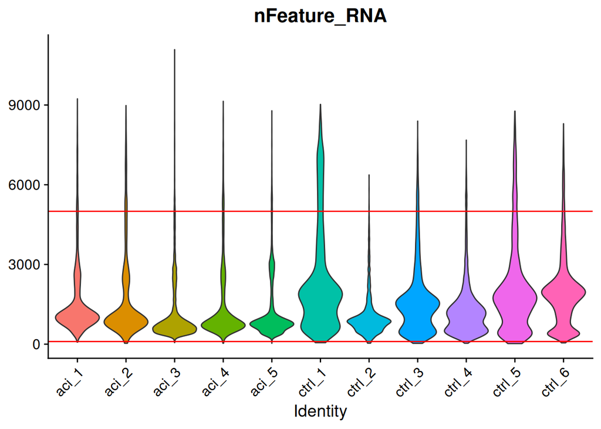

```r
vln_qc$before_sample[[1]] <-
  vln_qc$before_sample[[1]] +
  geom_hline(yintercept = 5000, col = "red") +
  geom_hline(yintercept = 100, col = "red")
vln_qc$before_sample[[1]]
```

```r
range(all_data_qc$nCount_RNA)
```

```
[1]    500 154080
```

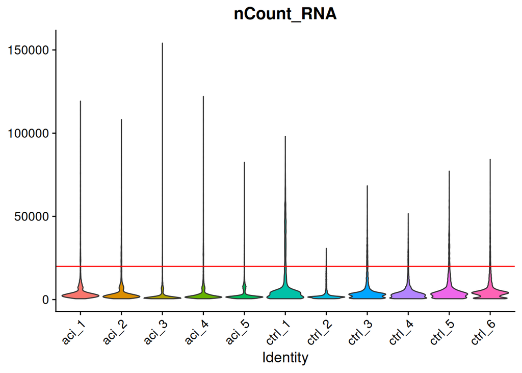

```r
vln_qc$before_sample[[2]] <-
  vln_qc$before_sample[[2]] +
  geom_hline(yintercept = 20000, col = "red")
vln_qc$before_sample[[2]]
```

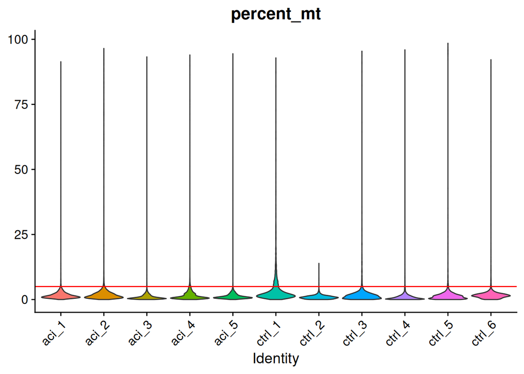

```r
vln_qc$before_sample[[3]] <-
  vln_qc$before_sample[[3]] +
  geom_hline(yintercept = 5, col = "red")
vln_qc$before_sample[[3]]
```

```r
# vln_qc$before_sample[[5]] <-
#   vln_qc$before_sample[[5]] +
#   geom_hline(yintercept = 25, col = "red")
# vln_qc$before_sample[[5]]
```

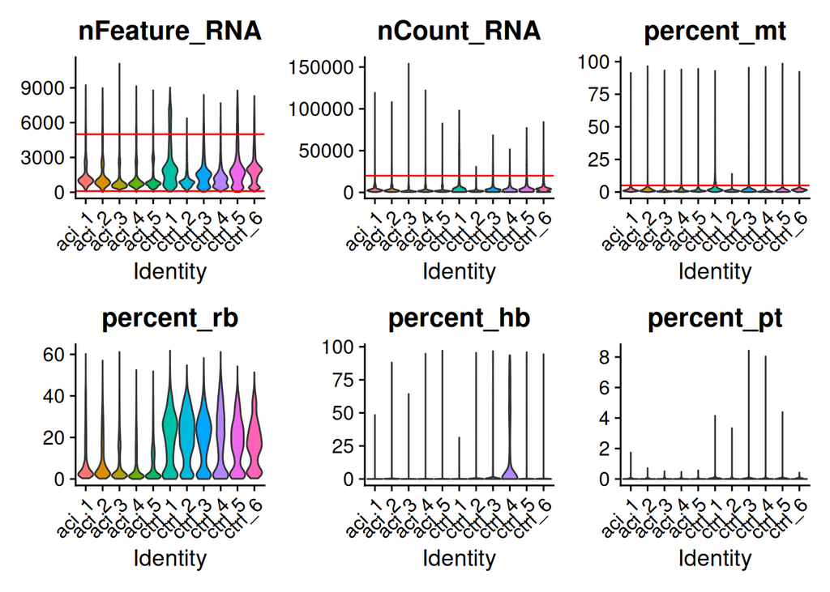

```r
vln_qc$before_sample
```

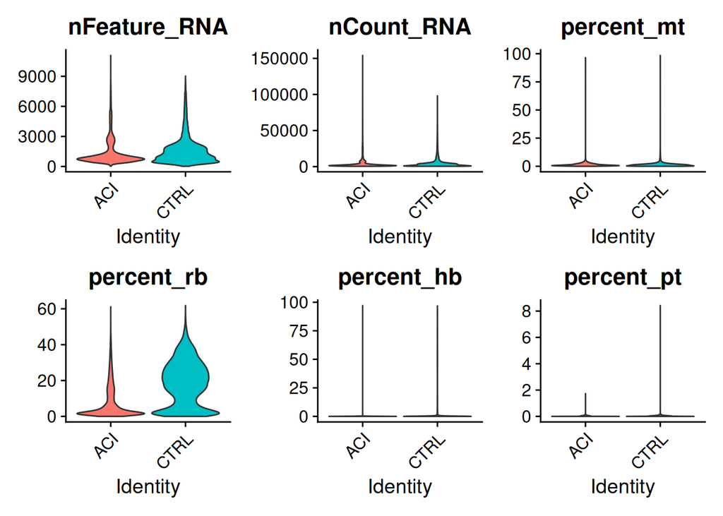

```r
vln_qc$before_group <-
  VlnPlot(all_data_qc, group.by = "group", layer = "counts",
          features = c("nFeature_RNA", "nCount_RNA", "percent_mt",
                       "percent_rb", "percent_hb", "percent_pt"),
          pt.size = 0,
          ncol = 3) + NoLegend()
vln_qc$before_group
```

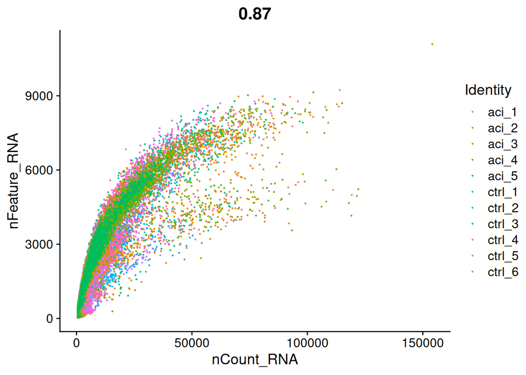

```r
FeatureScatter(
  all_data_qc,
  "nCount_RNA",
  "nFeature_RNA",
  group.by = "orig.ident",
  pt.size = 0.2
)
```

```r
qs_save(
  all_data_qc,
  file = "data/rdata/preprocess/all_data_qc.qs2",
  nthreads = 10
)
rm(all_data_qc)
gc()
```

```
           used  (Mb) gc trigger   (Mb)   max used   (Mb)
Ncells 11441727 611.1   20569462 1098.6   20569462 1098.6
Vcells 23551927 179.7  991233340 7562.6 1232058104 9399.9
```

### 4. Detection-based Filtering

按检出基因数和 UMI 去掉空液滴、信息量太低的细胞。看各样本剩下多少，有没有某一例被削得很狠。

```r
all_data_qc <- qs_read("data/rdata/preprocess/all_data_qc.qs2", nthreads = 10)
dim(all_data_qc)
```

```
[1] 38606 79488
```

```r
selected_c <- WhichCells(
  all_data_qc,
  slot = "counts",
  expression = nFeature_RNA > 100 &
    nFeature_RNA < 5000 &
    nCount_RNA < 20000
)
length(selected_c)
```

```
[1] 74403
```

```r
scales::percent(
  (dim(all_data_qc)[2] - length(selected_c)) / dim(all_data_qc)[2],
  accuracy = 0.01
)
```

```
[1] "6.40%"
```

```r
selected_f0 <- rownames(all_data_qc)[
  Matrix::rowSums(all_data_qc@assays$RNA$counts) > 0
]
length(selected_f0)
```

```
[1] 33077
```

```r
n_feature_sample <- rowSums(x = GetAssayData(all_data_qc, layer = "counts") > 0)
sum(n_feature_sample > 0)
```

```
[1] 33077
```

```r
length(n_feature_sample)
```

```
[1] 38606
```

```r
identical(selected_f0, names(n_feature_sample)[n_feature_sample > 0])
```

```
[1] TRUE
```

```r
selected_f <- names(n_feature_sample)[n_feature_sample > 100]
length(selected_f)
```

```
[1] 19681
```

```r
scales::percent(
  (length(n_feature_sample) - length(selected_f)) /
    length(n_feature_sample),
  accuracy = 0.01
)
```

```
[1] "49.02%"
```

```r
data_filt_qc <- subset(all_data_qc, cells = selected_c)
dim(data_filt_qc)
```

```
[1] 38606 74403
```

```r
dim(all_data_qc)
```

```
[1] 38606 79488
```

```r
rm(all_data_qc)
```

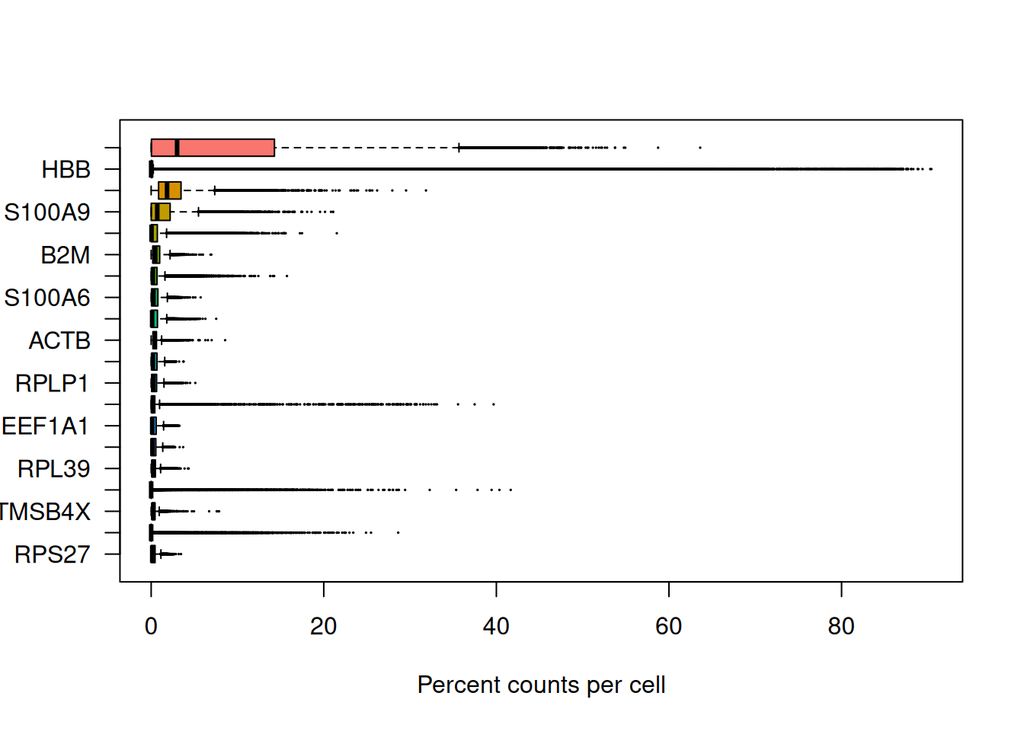

```r
counts_matrix <- data_filt_qc@assays$RNA$counts
counts_matrix@x <- counts_matrix@x /
  rep.int(colSums(counts_matrix), diff(counts_matrix@p)) * 100
most_expressed <- order(Matrix::rowSums(counts_matrix), decreasing = TRUE)[20:1]
boxplot(as.matrix(t(counts_matrix[most_expressed, ])),
        cex = 0.1, las = 1, xlab = "Percent counts per cell",
        col = (scales::hue_pal())(20)[20:1], horizontal = TRUE)
```

```r
rm(counts_matrix, most_expressed)
```

### 5. Mito/Ribo Filtering

```r
selected_mito <- WhichCells(
  data_filt_qc,
  slot = "counts",
  expression = percent_mt < 5
)
length(selected_mito)
```

```
[1] 72346
```

```r
pct_removed <- scales::percent(
  (dim(data_filt_qc)[2] - length(selected_mito)) / dim(data_filt_qc)[2],
  accuracy = 0.01
)
pct_removed
```

```
[1] "2.76%"
```

```r
data_filt_qc <- subset(data_filt_qc, cells = selected_mito)
dim(data_filt_qc)
```

```
[1] 38606 72346
```

```r
table(data_filt_qc$orig.ident) |> sort()
```

```
ctrl_1 ctrl_5 ctrl_3 ctrl_2 ctrl_6 ctrl_4  aci_4  aci_2  aci_1  aci_5  aci_3
  1953   2096   3671   6085   6828   6986   7871   8037   8064   9717  11038
```

Do not filter MT and RB genes

https://www.biostars.org/p/355658/

```r
# data_filt_qc <- data_filt_qc[!grepl("^MT-", rownames(data_filt_qc)), ]
# data_filt_qc <- data_filt_qc[!grepl("^RP[SL]", rownames(data_filt_qc)), ]
```

Violin plot after filtering

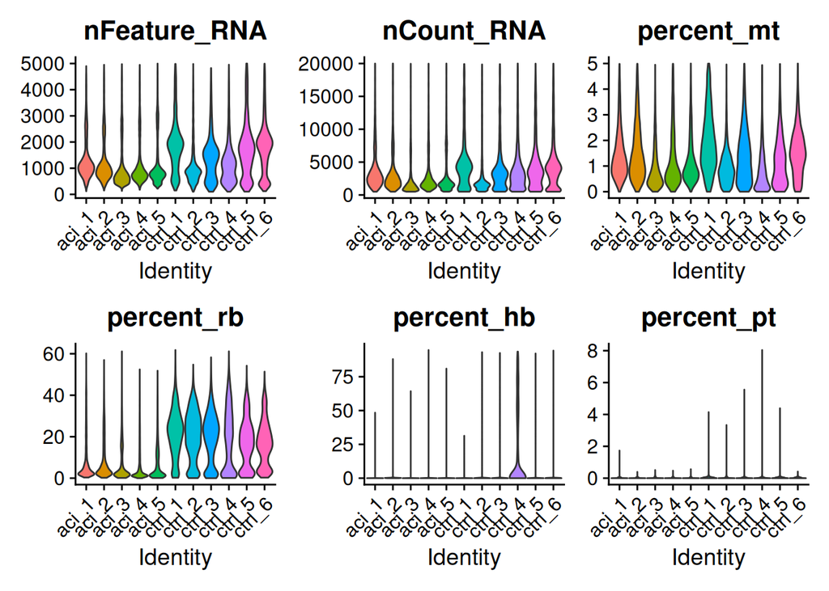

```r
vln_qc$after_sample <-
  VlnPlot(data_filt_qc, group.by = "orig.ident", layer = "counts",
          features = c("nFeature_RNA", "nCount_RNA", "percent_mt",
                       "percent_rb", "percent_hb", "percent_pt"),
          pt.size = 0,
          ncol = 3) + NoLegend()
vln_qc$after_sample
```

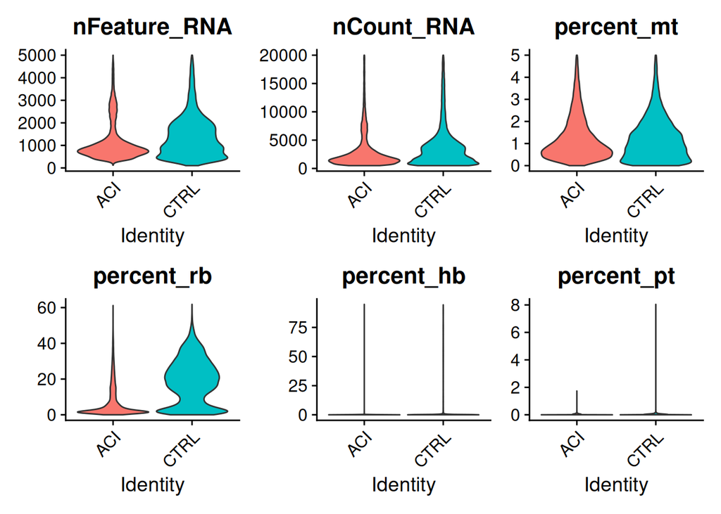

```r
vln_qc$after_group <-
  VlnPlot(data_filt_qc, group.by = "group", layer = "counts",
          features = c("nFeature_RNA", "nCount_RNA", "percent_mt",
                       "percent_rb", "percent_hb", "percent_pt"),
          pt.size = 0,
          ncol = 3) + NoLegend()
vln_qc$after_group
```

```r
qs_save(vln_qc, file = "data/rdata/preprocess/violin_qc.qs2", nthreads = 10)
rm(vln_qc)
gc()
```

```
            used   (Mb) gc trigger   (Mb)   max used   (Mb)
Ncells  11490351  613.7   20569462 1098.6   20569462 1098.6
Vcells 160602711 1225.4  792986672 6050.1 1232058104 9399.9
```

### (Skipped) Check Sample Sex

性别来自临床记录，不从表达推断。

```r
# suppressMessages(require(biomaRt))
# mart <- useMart("ENSEMBL_MART_ENSEMBL", dataset = "hsapiens_gene_ensembl")
#
# # fetch chromosome info plus some other annotations
# genes_table <- try(biomaRt::getBM(attributes = c("ensembl_gene_id",
#                                                  "external_gene_name",
#                                                  "description",
#                                                  "gene_biotype",
#                                                  "chromosome_name",
#                                                  "start_position"),
#                                   mart = mart, useCache = F))
# write_tsv(genes_table, "data/genes_table.tsv")
#
# genes_table <- read_tsv("data/genes_table.tsv")
#
# chrY_gene <-
#   genes_table |>
#   filter(!is.na(external_gene_name)) |>
#   filter(external_gene_name %in% rownames(data_filt_qc)) |>
#   filter(chromosome_name == "Y") |>
#   dplyr::select(external_gene_name) |>
#   pull
# length(chrY_gene)
#
# data_filt_qc$pct_chrY = colSums(data_filt_qc@assays$RNA$counts[chrY_gene, ]) / colSums(data_filt_qc@assays$RNA$counts)
#
# VlnPlot(data_filt_qc, features = c("XIST", "pct_chrY"), layer = "counts", group.by = "patient")
# sample_info
```

### 6. Cell Cycle Score

给每个细胞打一个周期分数，后面作图用。没有强制从表达里回归掉周期。

```r
# data_filt_qc <- qs_read("data/rdata/preprocess/data_filt_qc.qs2", nthreads = 10) # nolint
```

```r
data_filt_qc <- NormalizeData(data_filt_qc, verbose = TRUE)
```

```r
data_filt_qc <- CellCycleScoring(object = data_filt_qc,
                                 g2m.features = cc.genes.updated.2019$g2m.genes,
                                 s.features = cc.genes.updated.2019$s.genes)
colnames(data_filt_qc@meta.data)[12:14] <- c("s_score", "g2m_score", "phase")
```

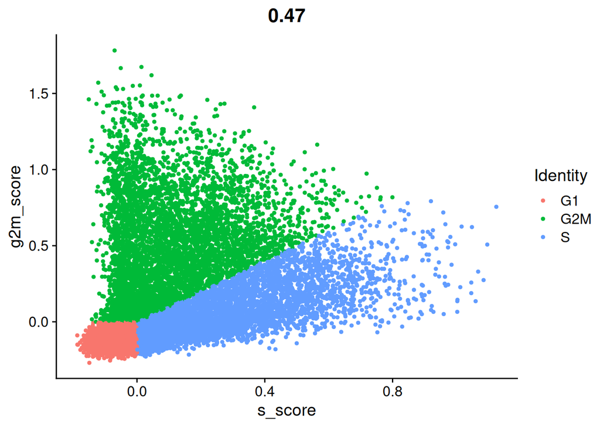

```r
FeatureScatter(data_filt_qc, "s_score", "g2m_score", group.by = "phase")
```

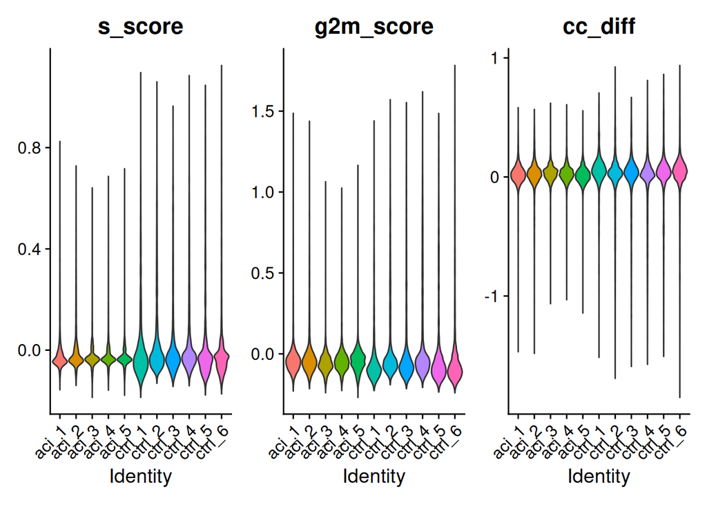

```r
data_filt_qc$cc_diff <- data_filt_qc$s_score - data_filt_qc$g2m_score
VlnPlot(data_filt_qc, features = c("s_score", "g2m_score", "cc_diff"),
        group.by = "orig.ident", ncol = 3, pt.size = 0)
```

```r
data_filt_qc[["RNA"]]$data <- NULL
qs_save(
  data_filt_qc,
  file = "data/rdata/preprocess/data_filt_qc.qs2",
  nthreads = 10
)
rm(
  data_filt_qc,
  n_feature_sample,
  selected_c,
  selected_f,
  selected_f0,
  selected_mito
)
```

### 7. Predict Doublets

预测两个细胞粘在一起的液滴。双细胞会把两种 marker 叠在同一个点上，干扰命名。

```r
data_prep <- qs_read(
  "data/rdata/preprocess/data_filt_qc.qs2",
  nthreads = 10
)
bp_param <- SnowParam(workers = 15, RNGseed = 123)

sce <- as.SingleCellExperiment(data_prep)
sce <- scDblFinder(sce, samples = "sample", clusters = TRUE, BPPARAM = bp_param)

identical(colnames(data_prep), colnames(sce))
```

```
[1] TRUE
```

```r
data_prep$is_doublet <- sce$scDblFinder.class
data_prep$doublet_score <- sce$scDblFinder.score
```

```r
qs_save(
  data_prep,
  file = "data/rdata/preprocess/data_prep.qs2",
  nthreads = 10
)
rm(sce, bp_param, data_prep)
```

### 8. Prepare Final Data

写出质控后的对象，后面聚类都读这份。

```r
data_prep <- qs_read(
  "data/rdata/preprocess/data_prep.qs2",
  nthreads = 10
)
Assays(data_prep)
```

```
An object of class "SimpleAssays"
Slot "data":
List of length 1
```

```r
dim(data_prep)
```

```
[1] 38606 72346
```

```r
data_prep$doublet_score |> range()
```

```
[1] 3.379262e-06 9.999934e-01
```

```r
doublet_fraction <-
  (dim(data_prep)[2] - sum(data_prep$is_doublet == "singlet")) /
  dim(data_prep)[2]
scales::percent(doublet_fraction, accuracy = 0.01)
```

```
[1] "7.33%"
```

```r
head(data_prep@meta.data)
```

```
                          orig.ident nCount_RNA nFeature_RNA sample group
ctrl_1_AAACCTGAGTCCGGTC-1     ctrl_1        519          436 CTRL-1  CTRL
ctrl_1_AAACCTGCAAGCGCTC-1     ctrl_1      18100         4470 CTRL-1  CTRL
ctrl_1_AAACCTGCAGACGCAA-1     ctrl_1       8300         3061 CTRL-1  CTRL
ctrl_1_AAACCTGTCAAGGTAA-1     ctrl_1        769          615 CTRL-1  CTRL
ctrl_1_AAACCTGTCACAATGC-1     ctrl_1        669          387 CTRL-1  CTRL
ctrl_1_AAACGGGCAGATGGCA-1     ctrl_1       5152         1881 CTRL-1  CTRL
                          gender age percent_mt percent_rb percent_hb
ctrl_1_AAACCTGAGTCCGGTC-1   Male  62  1.5414258   13.87283 0.19267823
ctrl_1_AAACCTGCAAGCGCTC-1   Male  62  0.9337017   42.37017 0.01104972
ctrl_1_AAACCTGCAGACGCAA-1   Male  62  2.4939759   22.16867 0.00000000
ctrl_1_AAACCTGTCAAGGTAA-1   Male  62  2.0806242   11.31339 1.69050715
ctrl_1_AAACCTGTCACAATGC-1   Male  62  1.3452915   18.98356 3.73692078
ctrl_1_AAACGGGCAGATGGCA-1   Male  62  1.5333851   39.46040 0.03881988
                          percent_pt     s_score   g2m_score phase    cc_diff
ctrl_1_AAACCTGAGTCCGGTC-1 0.00000000  0.09752453 -0.03345996     S 0.13098448
ctrl_1_AAACCTGCAAGCGCTC-1 0.01104972  0.59433181  0.05024735     S 0.54408446
ctrl_1_AAACCTGCAGACGCAA-1 0.02409639 -0.05256067 -0.09477101    G1 0.04221034
ctrl_1_AAACCTGTCAAGGTAA-1 0.13003901  0.07119995 -0.07176488     S 0.14296483
ctrl_1_AAACCTGTCACAATGC-1 0.00000000  0.14764930  0.03119341     S 0.11645589
ctrl_1_AAACGGGCAGATGGCA-1 0.09704969 -0.01050198 -0.04324619    G1 0.03274421
                          is_doublet doublet_score
ctrl_1_AAACCTGAGTCCGGTC-1    singlet   0.003584485
ctrl_1_AAACCTGCAAGCGCTC-1    singlet   0.139647678
ctrl_1_AAACCTGCAGACGCAA-1    singlet   0.154037639
ctrl_1_AAACCTGTCAAGGTAA-1    singlet   0.048985749
ctrl_1_AAACCTGTCACAATGC-1    singlet   0.002627888
ctrl_1_AAACGGGCAGATGGCA-1    singlet   0.023566755
```

```r
data_prep <-
  qs_read("data/rdata/preprocess/data_prep.qs2", nthreads = 10)
```

```r
data_prep <-
  NormalizeData(data_prep, verbose = TRUE)
data_prep <-
  FindVariableFeatures(data_prep, nfeatures = 3000)
data_prep <-
  ScaleData(data_prep) # vars.to.regress = c("nFeature_RNA", "percent_mt"))
data_prep <-
  RunPCA(data_prep)
data_prep <-
  RunUMAP(data_prep, dims = 1:30, reduction = "pca")
```

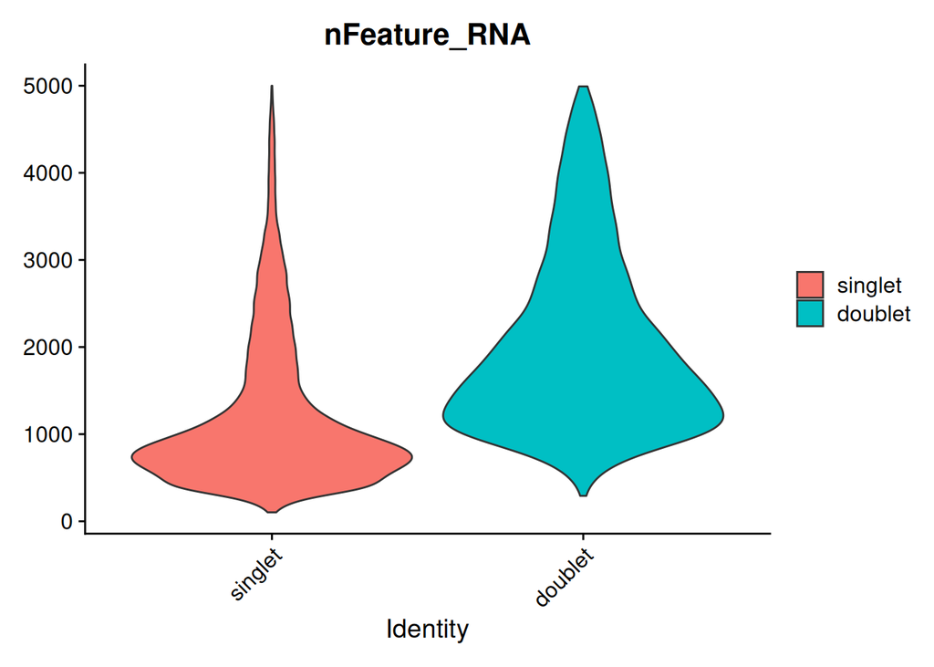

```r
VlnPlot(
  data_prep,
  features = "nFeature_RNA",
  group.by = "is_doublet",
  pt.size = 0
)
```

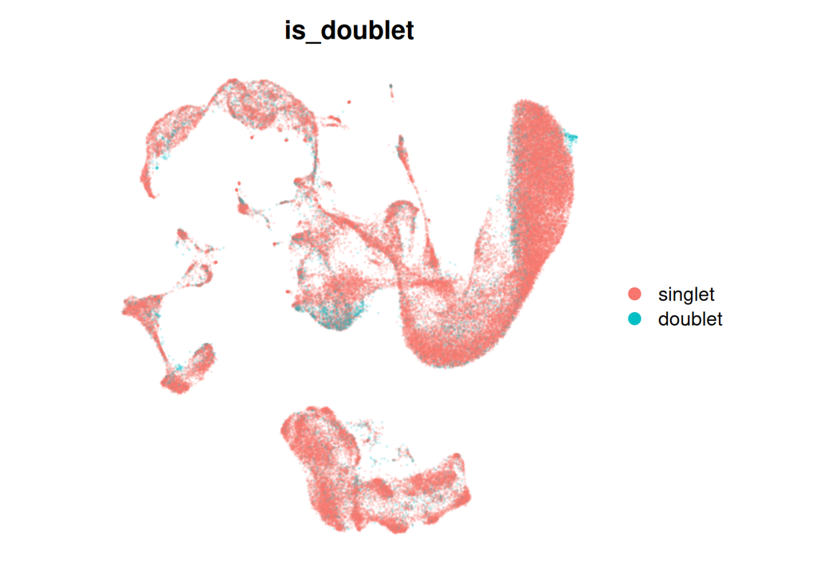

```r
DimPlot(
  data_prep,
  group.by = "is_doublet",
  raster = FALSE,
  pt.size = 0.1,
  alpha = 0.1
) +
  NoAxes() +
  theme(aspect.ratio = 1)
```